# HW2

## Introduction This report is created according to the data from 1 July to 31 July [Energy Exchange Istanbul(EXIST) page](https://rapor.epias.com.tr/rapor/xhtml/ptfSmfListeleme.xhtml).

```r
setwd("C:/Users/ABDULLAH/Desktop")

library(readr)
library(tidyverse)
library(lubridate)


veri<- read.csv("HW.csv",stringsAsFactors = TRUE, header=TRUE)

str(veri)
```

```
'data.frame':   744 obs. of  6 variables:
 $ Date                             : Factor w/ 744 levels "01.07.20 00:00",..: 1 2 3 4 5 6 7 8 9 10 ...
 $ MCP                              : num  324 327 324 322 320 ...
 $ SMP                              : num  211 201 211 211 201 ...
 $ Positive.Imbalance.Price..TL.MWh.: num  205 195 205 205 195 ...
 $ Negative.Imbalance.Price..TL.MWh.: num  334 337 334 332 330 ...
 $ SMP.Direction                    : Factor w/ 3 levels "Energy Deficit",..: 2 2 2 2 2 2 2 2 2 2 ...
```

So as to see changes , I use Glimpse() function. I also edited some columns in excel before starting this report.

```r
veri %>% glimpse()
```

```
Rows: 744
Columns: 6
$ Date                              <fct> 01.07.20 00:00, 01.07.20 01:00, 01.07.20 02:00, 01.07.20 03:00, 01.07.20 04:00, 01.07.20 05:00, 01.07.20 06:00, 01....
$ MCP                               <dbl> 323.85, 326.95, 324.31, 322.11, 320.00, 286.21, 210.13, 318.20, 324.85, 327.67, 329.60, 329.99, 324.21, 327.83, 332...
$ SMP                               <dbl> 211.00, 201.00, 211.00, 211.00, 201.00, 181.00, 113.75, 201.00, 181.00, 181.00, 250.00, 329.99, 342.80, 355.83, 377...
$ Positive.Imbalance.Price..TL.MWh. <dbl> 204.67, 194.97, 204.67, 204.67, 194.97, 175.57, 110.34, 194.97, 175.57, 175.57, 242.50, 320.09, 314.48, 318.00, 322...
$ Negative.Imbalance.Price..TL.MWh. <dbl> 333.57, 336.76, 334.04, 331.77, 329.60, 294.80, 216.43, 327.75, 334.60, 337.50, 339.49, 339.89, 353.08, 366.50, 388...
$ SMP.Direction                     <fct> Energy Surplus, Energy Surplus, Energy Surplus, Energy Surplus, Energy Surplus, Energy Surplus, Energy Surplus, Ene...
```

```r
data <- veri %>%
  rename(  d = Date, mcp = MCP, smp = SMP, pip = Positive.Imbalance.Price..TL.MWh., nip = Negative.Imbalance.Price..TL.MWh., sd = SMP.Direction)

data$d <- strptime(data$d,format="%d.%m.%y %H:%M")



data %>% glimpse()
```

```
Rows: 744
Columns: 6
$ d   <dttm> 2020-07-01 00:00:00, 2020-07-01 01:00:00, 2020-07-01 02:00:00, 2020-07-01 03:00:00, 2020-07-01 04:00:00, 2020-07-01 05:00:00, 2020-07-01 06:00:0...
$ mcp <dbl> 323.85, 326.95, 324.31, 322.11, 320.00, 286.21, 210.13, 318.20, 324.85, 327.67, 329.60, 329.99, 324.21, 327.83, 332.37, 331.29, 331.14, 330.81, 3...
$ smp <dbl> 211.00, 201.00, 211.00, 211.00, 201.00, 181.00, 113.75, 201.00, 181.00, 181.00, 250.00, 329.99, 342.80, 355.83, 377.37, 376.29, 375.00, 360.81, 3...
$ pip <dbl> 204.67, 194.97, 204.67, 204.67, 194.97, 175.57, 110.34, 194.97, 175.57, 175.57, 242.50, 320.09, 314.48, 318.00, 322.40, 321.35, 321.21, 320.89, 3...
$ nip <dbl> 333.57, 336.76, 334.04, 331.77, 329.60, 294.80, 216.43, 327.75, 334.60, 337.50, 339.49, 339.89, 353.08, 366.50, 388.69, 387.58, 386.25, 371.63, 3...
$ sd  <fct> Energy Surplus, Energy Surplus, Energy Surplus, Energy Surplus, Energy Surplus, Energy Surplus, Energy Surplus, Energy Surplus, Energy Surplus, E...
```

##General Information about dataset

Some statistics like min, quartile , median and max can be seen below.

Also, It can be seen that SMP values are higher than MCP values. So, we can mention about energy deficit for those.

```r
data %>% summarise(count=n())
```

| count |
| --- |
| 744 |

```r
data %>% filter(sd == "Energy Deficit") %>% summarise(count=n())
```

| count |
| --- |
| 528 |

```r
data %>% filter(sd == "In Balance") %>% summarise(count=n())
```

| count |
| --- |
| 21 |

```r
data %>% filter(sd == "Energy Surplus") %>% summarise(count=n())
```

| count |
| --- |
| 195 |

```r
data %>% summary
```

```
       d                            mcp             smp             pip             nip                     sd
 Min.   :2020-07-01 00:00:00   Min.   :140.0   Min.   : 10.0   Min.   :  9.7   Min.   :144.2   Energy Deficit:528
 1st Qu.:2020-07-08 17:45:00   1st Qu.:300.0   1st Qu.:250.0   1st Qu.:228.2   1st Qu.:312.9   Energy Surplus:195
 Median :2020-07-16 11:30:00   Median :306.6   Median :320.0   Median :293.4   Median :331.9   In Balance    : 21
 Mean   :2020-07-16 11:30:00   Mean   :296.4   Mean   :299.3   Mean   :268.6   Mean   :328.3
 3rd Qu.:2020-07-24 05:15:00   3rd Qu.:317.0   3rd Qu.:345.0   3rd Qu.:304.1   3rd Qu.:355.4
 Max.   :2020-07-31 23:00:00   Max.   :350.0   Max.   :460.0   Max.   :339.5   Max.   :473.8
```

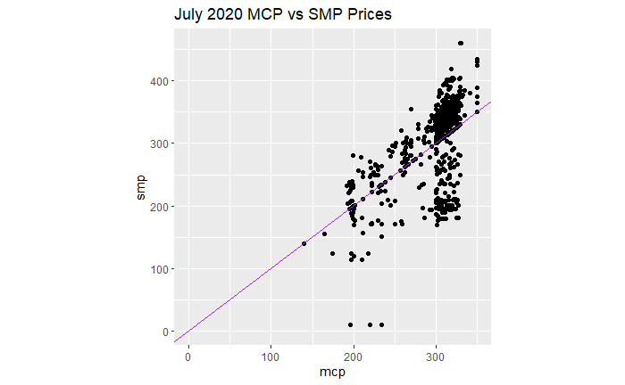

```r
ggplot(data, aes(x=mcp, y=smp)) + geom_point() + theme(aspect.ratio=1)+ xlim(0,350) + ylim(0,460) + ggtitle("July 2020 MCP vs SMP Prices  ") + labs(x = "mcp", y = "smp") + geom_abline(slope=1, intercept=0, color="purple")
```

###Observing MCP Hourly

In energy industry, data is collected as hourly. In this report, data is extracted from July 1 to July 31. The price changes regarding the hour of the day should be observed. In the graph, you can see relationship `MCP` vs. `hour_of_day` for same hours

It can be observed that there maybe a relationship between same hours of different days,

I also create second ggplot to calculate the hourly average values for each hour.

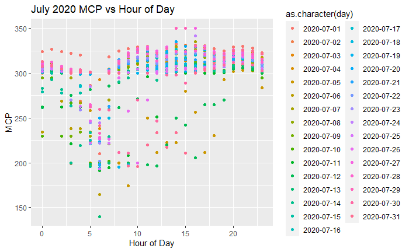

```r
plot_one <- data %>% group_by(hour_of_day = lubridate::hour(d), day=lubridate::date(d))
ggplot(plot_one, aes(x = hour_of_day, y = mcp, color=as.character(day))) + geom_point() + ggtitle("July 2020 MCP vs Hour of Day ") + labs(x="Hour of Day", y="MCP")
```

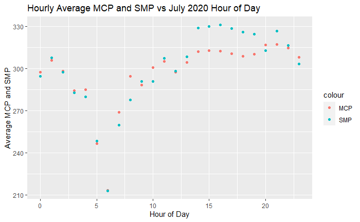

```r
plot_two<-data %>% group_by(hour_of_day = lubridate::hour(d)) %>% summarise(avg_MCP = mean(mcp), avg_SMP = mean(smp))
ggplot(plot_two) + geom_point(aes(x = hour_of_day, y = avg_MCP, color="MCP")) + geom_point(aes(x = hour_of_day, y = avg_SMP, color="SMP")) + ggtitle("Hourly Average MCP and SMP vs July 2020 Hour of Day") + labs(x="Hour of Day", y="Average MCP and SMP")
```

```r
NA
NA
NA
```

Here you can see average values of MCP and SMP

```r
plot_three <- data %>% group_by(day = lubridate::day(d)) %>% summarise(daily_avg_MCP= mean(mcp), daily_avg_SMP= mean(smp),daily_avg_pip=mean(pip),daily_avg_nip=mean(nip))
print(plot_three)
```

| day | daily_avg_MCP | daily_avg_SMP | daily_avg_pip | daily_avg_nip |
| --- | --- | --- | --- | --- |
| 1 | 320.1354 | 268.3675 | 250.1075 | 340.5804 |
| 2 | 298.2683 | 356.9079 | 289.3196 | 367.6158 |
| 3 | 316.6133 | 372.7733 | 307.1150 | 383.9563 |
| 4 | 306.0008 | 321.3442 | 291.7663 | 336.3517 |
| 5 | 257.5275 | 197.7721 | 191.8388 | 265.2529 |
| 6 | 290.1829 | 306.9533 | 280.3062 | 317.4054 |
| 7 | 306.9558 | 298.1183 | 276.5346 | 329.5863 |
| 8 | 304.0046 | 190.8692 | 185.1421 | 313.1238 |
| 9 | 288.2375 | 188.8638 | 183.1979 | 296.8850 |
| 10 | 281.8229 | 291.8733 | 269.6488 | 304.5788 |

[output cut: 21 more lines]

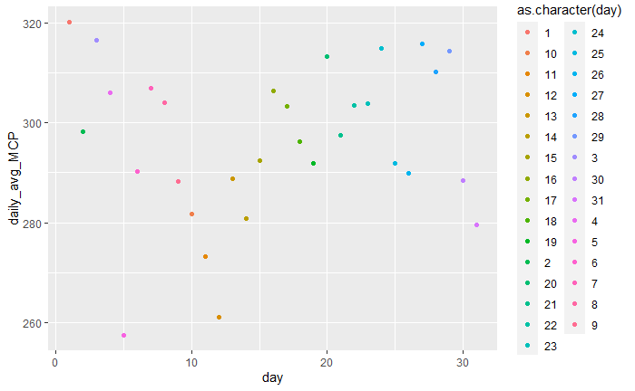

```r
ggplot(plot_three) + geom_point(aes(x = day, y = daily_avg_MCP, color=as.character(day)))
```

The first graph shows that MCP is getting higher after morning hour by hour.

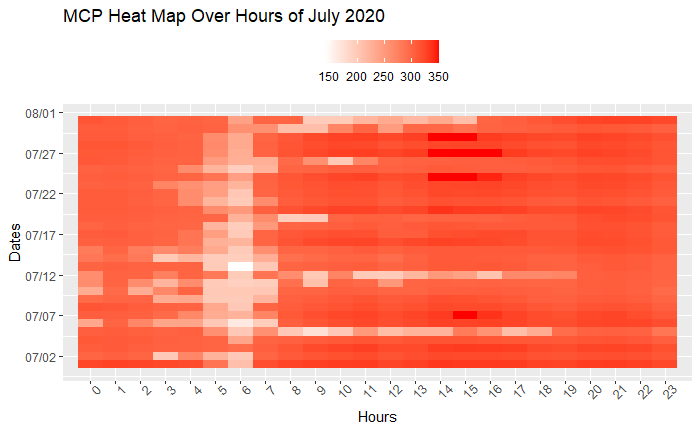

```r
plot_four <- data %>% group_by(hour_of_day = lubridate::hour(d), day=lubridate::date(d))
ggplot(plot_four, aes(x = hour_of_day, y = day, fill=mcp)) +
  geom_point() +
  ggtitle("MCP Heat Map Over Hours of July 2020") +
  geom_tile() +
  scale_fill_gradient(low="white", high="red") +
  labs(x = "Hours",
       y = "Dates") +
  scale_y_date(date_breaks = "5 day", date_labels = "%m/%d") +
  scale_x_discrete(limits=c(0:23)) +
  theme(axis.text.x = element_text(angle = 45), legend.position = "top",
        legend.title = element_blank())
```

```r
print(plot_four)
```

| d | mcp | smp | pip | nip | sd | hour_of_day | day |
| --- | --- | --- | --- | --- | --- | --- | --- |
|  | 323.85 | 211.00 | 204.67 | 333.57 | Energy Surplus | 0 | 2020-07-01 |
|  | 326.95 | 201.00 | 194.97 | 336.76 | Energy Surplus | 1 | 2020-07-01 |
|  | 324.31 | 211.00 | 204.67 | 334.04 | Energy Surplus | 2 | 2020-07-01 |
|  | 322.11 | 211.00 | 204.67 | 331.77 | Energy Surplus | 3 | 2020-07-01 |
|  | 320.00 | 201.00 | 194.97 | 329.60 | Energy Surplus | 4 | 2020-07-01 |
|  | 286.21 | 181.00 | 175.57 | 294.80 | Energy Surplus | 5 | 2020-07-01 |
|  | 210.13 | 113.75 | 110.34 | 216.43 | Energy Surplus | 6 | 2020-07-01 |
|  | 318.20 | 201.00 | 194.97 | 327.75 | Energy Surplus | 7 | 2020-07-01 |
|  | 324.85 | 181.00 | 175.57 | 334.60 | Energy Surplus | 8 | 2020-07-01 |
|  | 327.67 | 181.00 | 175.57 | 337.50 | Energy Surplus | 9 | 2020-07-01 |

[output cut: 734 more lines]

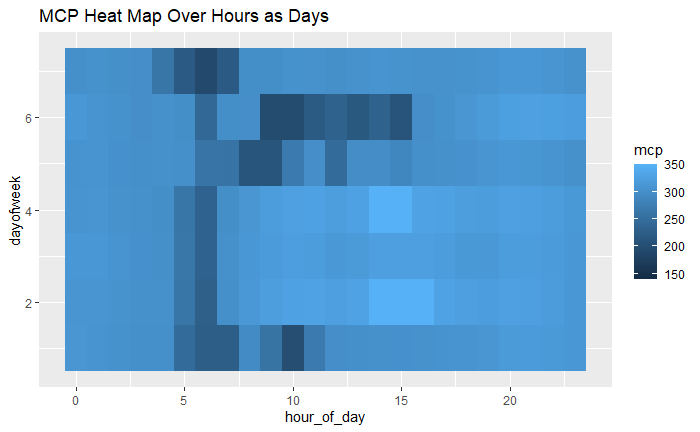

```r
plot_five <- data %>% group_by(hour_of_day = lubridate::hour(d), dayofweek = lubridate::wday(d))
ggplot(plot_five, aes(x = hour_of_day, y = dayofweek , fill=mcp)) +  ggtitle("MCP Heat Map Over Hours as Days") +

  geom_tile()
```

```r
print(plot_five)
```

| d | mcp | smp | pip | nip | sd | hour_of_day | dayofweek |
| --- | --- | --- | --- | --- | --- | --- | --- |
|  | 323.85 | 211.00 | 204.67 | 333.57 | Energy Surplus | 0 | 4 |
|  | 326.95 | 201.00 | 194.97 | 336.76 | Energy Surplus | 1 | 4 |
|  | 324.31 | 211.00 | 204.67 | 334.04 | Energy Surplus | 2 | 4 |
|  | 322.11 | 211.00 | 204.67 | 331.77 | Energy Surplus | 3 | 4 |
|  | 320.00 | 201.00 | 194.97 | 329.60 | Energy Surplus | 4 | 4 |
|  | 286.21 | 181.00 | 175.57 | 294.80 | Energy Surplus | 5 | 4 |
|  | 210.13 | 113.75 | 110.34 | 216.43 | Energy Surplus | 6 | 4 |
|  | 318.20 | 201.00 | 194.97 | 327.75 | Energy Surplus | 7 | 4 |
|  | 324.85 | 181.00 | 175.57 | 334.60 | Energy Surplus | 8 | 4 |
|  | 327.67 | 181.00 | 175.57 | 337.50 | Energy Surplus | 9 | 4 |

[output cut: 734 more lines]

```r
NA
NA
NA
```